# AS3-2: 股市動態

第 八 組

2019-03-10 14:19:51

**股票動態**

股票市場是買賣雙方交易公司股票的地方，也是個人和公司投資的最受歡迎的方式之一。現在估計世界股票市場規模達到數兆。紐約證券交易所位於紐約市，是世界上最大的股票市場。 紐約證券交易所約有2,800家上市公司。在這個問題上，我們將看看其中五家公司的每月股價：IB、通用電氣（GE）、寶潔、可口可樂和波音。此問題中使用的數據來自Infochimps。

使用`read.csv()`下載並讀取以下文件：

- `data/IBMStock.csv`
- `data/GEStock.csv`
- `data/ProcterGambleStock.csv`
- `data/CocaColaStock.csv`
- `data/BoeingStock.csv`

分別存入資料框`IBM`、`GE`、`ProcterGamble`、`CocaCola`和`Boeing`， 每個資料框都有兩個變量，描述如下：

- `Date`：日期
- `StockPrice`：給定月份公司的平均股價

在這個案例，我們將看看這些公司的股票動態如何隨著時間的推移而發生變化。

### Section-1 Summary Statistics

**§ 1.1** Our five datasets all have the same number of observations. How many observations are there in each data set?

```r
D_IBM = read.csv("data/IBMStock.csv", stringsAsFactors=F)
nrow(D_IBM)
```

```
[1] 480
```

```r
D_GE = read.csv("data/GEStock.csv", stringsAsFactors=F)
nrow(D_GE)
```

```
[1] 480
```

```r
D_PG = read.csv("data/ProcterGambleStock.csv", stringsAsFactors=F)
nrow(D_PG)
```

```
[1] 480
```

```r
D_CC = read.csv("data/CocaColaStock.csv", stringsAsFactors=F)
nrow(D_CC)
```

```
[1] 480
```

```r
D_B = read.csv("data/BoeingStock.csv", stringsAsFactors=F)
nrow(D_B)
```

```
[1] 480
```

```r
D_B$company=as.factor("B")
D_CC$company=as.factor("CC")
D_GE$company=as.factor("GE")
D_IBM$company=as.factor("IBM")
D_PG$company=as.factor("PG")
alldata = rbind(D_B,D_CC,D_GE,D_IBM,D_PG)
```

**§ 1.2** What is the earliest year in our datasets?

```r
D_B$Date = as.Date(D_B$Date, format="%m/%d/%y")
D_CC$Date = as.Date(D_CC$Date, format="%m/%d/%y")
D_GE$Date = as.Date(D_GE$Date, format="%m/%d/%y")
D_IBM$Date = as.Date(D_IBM$Date, format="%m/%d/%y")
D_PG$Date = as.Date(D_PG$Date, format="%m/%d/%y")
alldata$Date = as.Date(alldata$Date, format="%m/%d/%y")
min(D_IBM$Date)
```

```
[1] "1970-01-01"
```

**§ 1.3** What is the latest year in our datasets?

```r
max(D_IBM$Date)
```

```
[1] "2009-12-01"
```

**§ 1.4** What is the mean stock price of IBM over this time period?

```r
mean(D_IBM$StockPrice)
```

```
[1] 144.4
```

**§ 1.5** What is the minimum stock price of General Electric (GE) over this time period?

```r
min(D_GE$StockPrice)
```

```
[1] 9.294
```

**§ 1.6** What is the maximum stock price of Coca-Cola over this time period?

```r
max(D_CC$StockPrice)
```

```
[1] 146.6
```

**§ 1.7** What is the median stock price of Boeing over this time period?

```r
median(D_B$StockPrice)
```

```
[1] 44.88
```

**§ 1.8** What is the standard deviation of the stock price of Procter & Gamble over this time period?

```r
sd(D_PG$StockPrice)
```

```
[1] 18.19
```

### Section-2 Visualizing Stock Dynamics

**§ 2.1** Around what year did Coca-Cola has its highest stock price in this time period? Around what year did Coca-Cola has its lowest stock price in this time period?

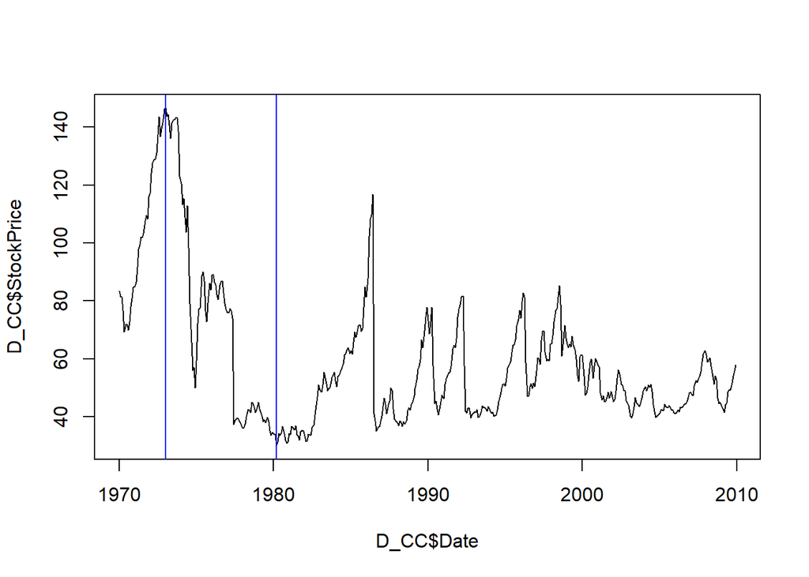

```r
plot(D_CC$Date , D_CC$StockPrice, type = "l")
abline(v = D_CC$Date[which.max(D_CC$StockPrice)], col = "blue")
abline(v = D_CC$Date[which.min(D_CC$StockPrice)], col = "blue")
```

```r
D_CC$Date[which.max(D_CC$StockPrice)]
```

```
[1] "1973-01-01"
```

```r
D_CC$Date[which.min(D_CC$StockPrice)]
```

```
[1] "1980-03-01"
```

# 1973-01-01

# 1980-03-01

**§ 2.2** In March of 2000, the technology bubble burst, and a stock market crash occurred. According to this plot, which company’s stock dropped more?

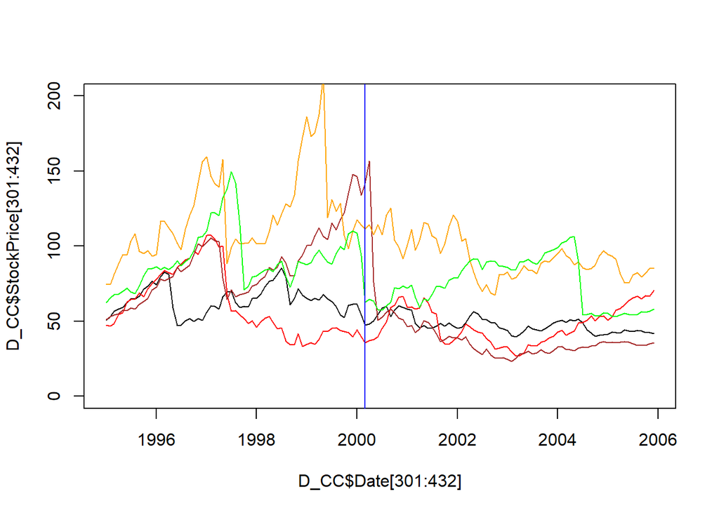

```r
plot(D_CC$Date[301:432] , D_CC$StockPrice[301:432], type = "l", col="black" , ylim = c(0 , 200))
lines(D_B$Date[301:432] , D_B$StockPrice[301:432], type = "l", col="red" , ylim = c(0 , 200))
lines(D_GE$Date[301:432] , D_GE$StockPrice[301:432], type = "l", col="brown" , ylim = c(0 , 200))
lines(D_IBM$Date[301:432] , D_IBM$StockPrice[301:432], type = "l", col="orange" , ylim = c(0 , 200))
lines(D_PG$Date[301:432] , D_PG$StockPrice[301:432], type = "l", col="green" , ylim = c(0 , 200))
abline(v = as.Date("2000-03-01") , col = "blue")
```

#General Electric (GE)

**§ 2.3** (a) Around 1983, the stock for one of these companies (Coca-Cola or Procter and Gamble) was going up, while the other was going down. Which one was going up?

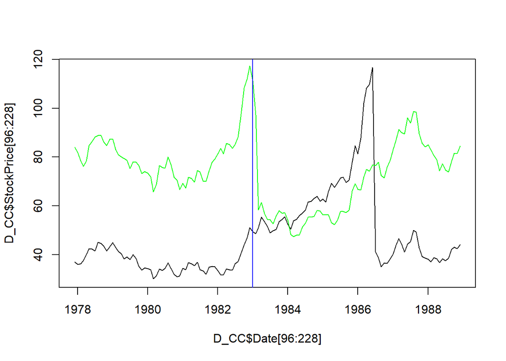

```r
plot(D_CC$Date[96:228] , D_CC$StockPrice[96:228], type = "l", col="black")
lines(D_PG$Date[96:228] , D_PG$StockPrice[96:228], type = "l", col="green")
abline(v = as.Date("1983-01-01") , col = "blue")
```

#Coca-Cola was going up, while Procter and Gamble was going down.

2. In the time period shown in the plot, which stock generally has lower values?

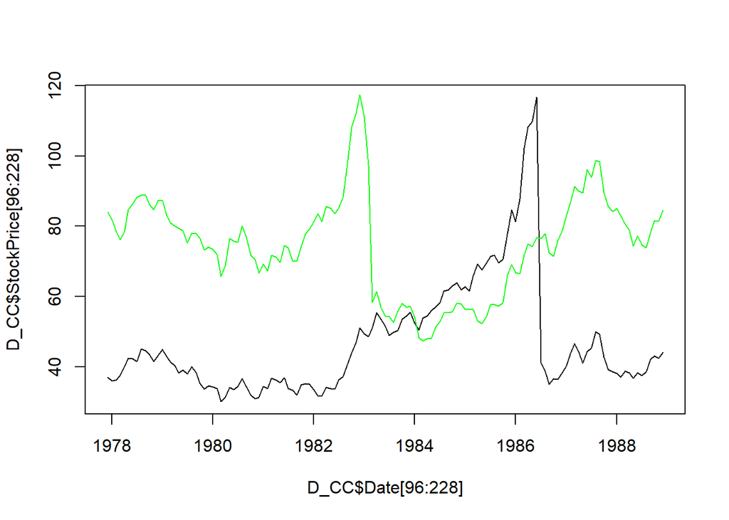

```r
plot(D_CC$Date[96:228] , D_CC$StockPrice[96:228], type = "l", col="black")
lines(D_PG$Date[96:228] , D_PG$StockPrice[96:228], type = "l", col="green")
```

#Coca-Cola

### Section-3 Visualizing Stock Dynamics 1995-2005

**§ 3.1** Which stock fell the most right after the technology bubble burst in March 2000?

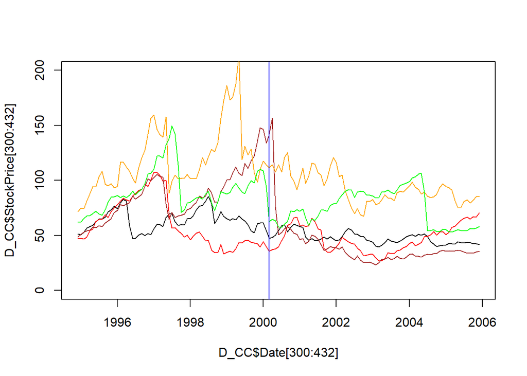

```r
plot(D_CC$Date[300:432] , D_CC$StockPrice[300:432], type = "l", col="black" , ylim = c(0 , 200))
lines(D_B$Date[300:432] , D_B$StockPrice[300:432], type = "l", col="red")
lines(D_GE$Date[300:432] , D_GE$StockPrice[300:432], type = "l", col="brown")
lines(D_IBM$Date[300:432] , D_IBM$StockPrice[300:432], type = "l", col="orange")
lines(D_PG$Date[300:432] , D_PG$StockPrice[300:432], type = "l", col="green")
abline(v = as.Date("2000-03-01") , col = "blue")
```

#General Electric (GE)

**§ 3.2** Which stock reaches the highest value in the time period 1995-2005?

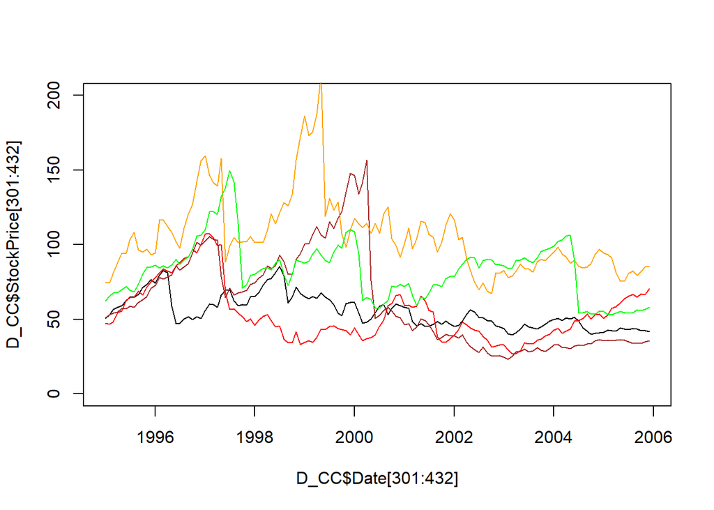

```r
plot(D_CC$Date[301:432] , D_CC$StockPrice[301:432], type = "l", col="black" , ylim = c(0 , 200))
lines(D_B$Date[301:432] , D_B$StockPrice[301:432], type = "l", col="red" , ylim = c(0 , 200))
lines(D_GE$Date[301:432] , D_GE$StockPrice[301:432], type = "l", col="brown" , ylim = c(0 , 200))
lines(D_IBM$Date[301:432] , D_IBM$StockPrice[301:432], type = "l", col="orange" , ylim = c(0 , 200))
lines(D_PG$Date[301:432] , D_PG$StockPrice[301:432], type = "l", col="green" , ylim = c(0 , 200))
```

#IBM

**§ 3.3** In October of 1997, there was a global stock market crash that was caused by an economic crisis in Asia. Comparing September 1997 to November 1997, which companies saw a decreasing trend in their stock price? (Select all that apply.)

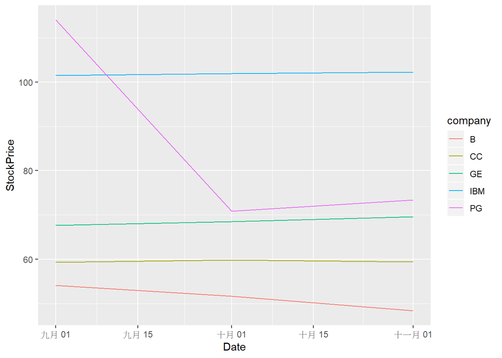

```r
library(ggplot2)
ggplot(filter(alldata,Date>="1997-09-01"&Date<="1997-11-30"),aes(x=Date,y=StockPrice,colour=company))+
  geom_line()
```

**§ 3.4** In the last two years of this time period (2004 and 2005) which stock seems to be performing the best, in terms of increasing stock price?

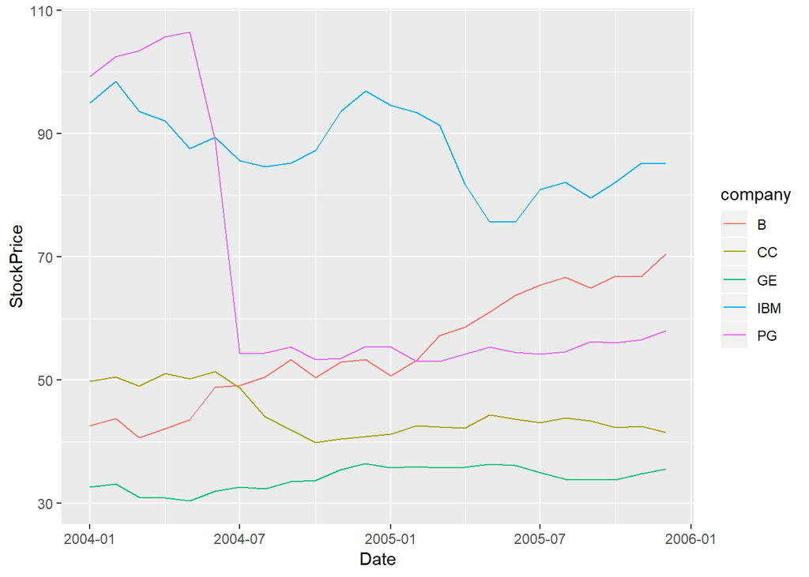

```r
ggplot(filter(alldata,Date>="2004-01-01"&Date<="2005-12-31"),aes(x=Date,y=StockPrice,colour=company))+
  geom_line()
```

### Section-4 Monthly Trends

**§ 4.1** For IBM, compare the monthly averages to the overall average stock price. In which months has IBM historically had a higher stock price (on average)? Select all that apply.

```r
sort(tapply(D_IBM$StockPrice,months(D_IBM$Date),mean),decreasing = T)
```

```
  二月   三月   四月   五月   一月 十二月   八月   六月   九月   七月 十一月   十月
 152.7  152.4  152.1  151.5  150.2  140.8  140.1  139.1  139.1  139.1  138.0  137.3
```

```r
mean(D_IBM$StockPrice)
```

```
[1] 144.4
```

# 二月,三月,四月,五月,一月

**§ 4.2** General Electric and Coca-Cola both have their highest average stock price in the same month. Which month is this?

```r
sort(tapply(D_GE$StockPrice,months(D_GE$Date),mean),decreasing = T)
```

```
  四月   三月   二月   一月   五月 十二月 十一月   七月   八月   六月   九月   十月
 64.48  63.15  62.52  62.05  60.87  59.10  57.29  56.73  56.50  56.47  56.24  56.24
```

```r
sort(tapply(D_CC$StockPrice,months(D_CC$Date),mean),decreasing = T)
```

```
  四月   三月   五月   六月   二月   一月 十二月 十一月   七月   八月   十月   九月
 62.69  62.07  61.44  60.81  60.73  60.37  59.73  59.10  58.98  58.88  57.94  57.60
```

# 四月

**§ 4.3** For the months of December and January, every company’s average stock is higher in one month and lower in the other. In which month are the stock prices lower?

```r
tapply(D_GE$StockPrice,months(D_GE$Date),mean)
```

```
  一月   七月   九月   二月   八月 十一月 十二月   十月   三月   五月   六月   四月
 62.05  56.73  56.24  62.52  56.50  57.29  59.10  56.24  63.15  60.87  56.47  64.48
```